# Developing Data Products Week 4 Project

November 15th, 2020

## Information

This short presentation is to summarize my Coronavirus Visualization App.

I created this app in April and have slowly added different features to it.

It allows a user to look at cumulative cases and deaths at anytime from January 2020 to present by states and counties.

There are graphs, maps, growth information, and compared metrics. I will use my home state NC for a few examples.

Here is a sample graph for NC Cases. In the app, this information can be for states or counties, for a specified date, and for one of five different metrics.

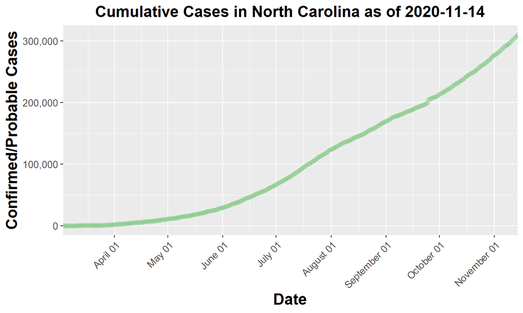

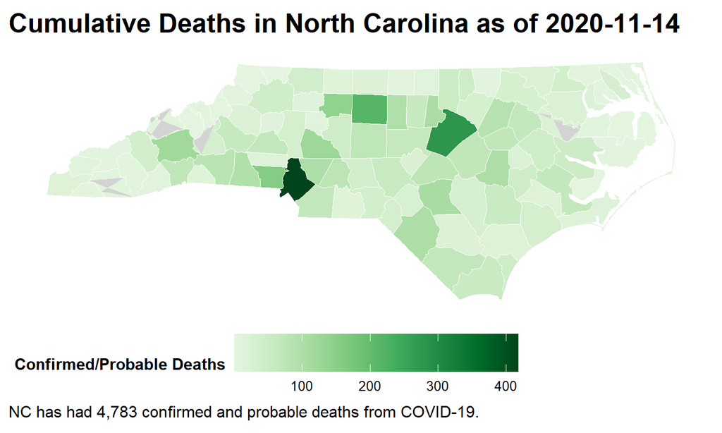

Here is a sample table for comparing NC and its counties. In the app, this can be displayed for the US and states, or for any state and its respective counties. More metrics are included.

```
                   Population  Cases Deaths Cases_resulting_in_Death
North Carolina       10488084 309703   4783                    1.54%
Mecklenburg County    1110356  38109    417                    1.09%
Wake County           1111761  24740    280                    1.13%
Guilford County        537174  13827    216                    1.56%
Forsyth County         382295  10740    141                    1.31%
Durham County          321488  10216    105                    1.03%
Gaston County          224529   8760    157                    1.79%
Cumberland County      335509   8129    108                    1.33%
Pitt County            180742   6958     44                    0.63%
Union County           239859   6739     67                    0.99%
Robeson County         130625   6686    102                    1.53%
Johnston County        209339   6622     70                    1.06%
New Hanover County     234473   6092     47                    0.77%
Alamance County        169509   6006     96                     1.6%
Cabarrus County        216453   5778    100                    1.73%
```

USA, County, State, and Territory Data:

[Data from The New York Times, based on reports from state and local health agencies.](https://github.com/nytimes/covid-19-data)

NC and Counties Population:

[County Population Totals: 2010-2019](https://www2.census.gov/programs-surveys/popest/datasets/2010-2019/counties/totals/co-est2019-alldata.csv)

App Code:

[GitHub Repository](https://github.com/HumanRickshaw/Coronavirus_Visualization)

Questions? Comments?

rohan.lewis@gmail.com